# 1_dosage_analysis

Kirk Amundson

2020_1007

Aim: Analyses pertaining to Figure 2 in the MM manuscript.

## Packages:

```r
library(tidyverse)
library(grid)
library(ggpubr)
library(ggbeeswarm)
library(viridis)
```

## Functions:

```r
melt_bin_alleles <- function(x) {
  df <- read_tsv(x, na = ".")

  nhi <- str_extract(x, "alleles_[A-Za-z0-9]+") %>%
    str_remove("alleles_") %>%
    str_remove("x.+$") %>%
    str_replace("93003", "93.003")

  hi <- str_extract(x, "alleles_[A-Za-z0-9]+") %>%
    str_remove("alleles_") %>%
    str_remove("^[A-Za-z0-9.]+x")

  ObsHI <- df %>%
    dplyr::select(Chrom,Start,End,Max,matches("Obs%A$")) %>%
    mutate(chrbin = floor(Start/df$End[1])) %>%
    gather(Ind, ObsPerHI, -Chrom, -Start, -End, -Max, -chrbin) %>%
    mutate(Ind = str_replace_all(Ind, "v-(.+)-Obs%A", "\\1"))

  CalcHI <- df %>%
    dplyr::select(Chrom, Start, End, Max, matches('Calc%A$')) %>%
    mutate(chrbin = floor(Start/df$End[1])) %>%
    gather(Ind, CalcPerHI, -Chrom, -Start, -End, -Max, -chrbin) %>%
    mutate(Ind = str_replace_all(Ind, "v-(.+)-Calc%A", "\\1"))

  Cov <- df %>%
    dplyr::select(Chrom, Start, End, Max, matches('Cov$')) %>%
    mutate(chrbin = floor(Start/df$End[1])) %>%
    gather(Ind, Cov, -Chrom, -Start, -End, -Max, -chrbin) %>%
    mutate(Ind = str_replace_all(Ind, "v-(.+)-Cov", "\\1"))

  df2 <- ObsHI %>%
    inner_join(.,Cov) %>%
    mutate(HIcalls = round(Cov * ObsPerHI / 100)) %>%
    filter(Chrom %in% sprintf("chr%0.2d", 1:12)) %>%
    # filter(!grepl("sub", Ind)) %>%
    # mutate(prenducer = str_extract(Ind, "(SRR6123031)|(SRR6123183)")) %>%
    # mutate(Inducer = ifelse(prenducer == "SRR6123031", "PL4", NA)) %>%
    # mutate(Inducer = ifelse(prenducer == "SRR6123183", "IVP101", Inducer)) %>%
    mutate(ObsPerHI_filt = ifelse(Cov >= 10, ObsPerHI, NA)) %>%
    mutate(start_cen = Start + (End-Start)/2) %>%
    mutate(Non_inducer = nhi,
           Inducer = hi)
  # print(head(df2))

  return(df2)
}
```

```r
# maps midpoints for plotting
chrom_midpoints <- function(x) {
  n=floor(nrow(x)/2)
  return(x$bin2[n])
}
```

```r
call_aneuploids <- function(df, parent, min_readcount = 2.5e5, bad_samples) {
  fam <- df %>%
    filter(!UCD_Sample_Code %in% bad_samples) %>%
    filter(sample_tot >= min_readcount) %>%
    filter(Non_inducer == parent) %>%
    filter(snp_ploidy == "2x" | is.na(snp_ploidy)) %>%
    mutate(manual_fp = ifelse(is.na(manual_fp), "tp", "fp")) %>%
    mutate(chromshort = str_remove(chrom, "chr")) %>%
    mutate(chromshort = str_remove(chromshort, "^0")) %>%
    dplyr::select(UCD_Sample_Code, UCD_Sample_Numeric, chrom, sample_tot, Non_inducer, manual_fp, chrom_normcov, ctrl_CIP, snp_ploidy) %>%
    distinct() %>%
    arrange(UCD_Sample_Numeric) %>%
    mutate(sample_num_recode = floor( (seq(1:nrow(.)) -0.01)  / length(unique(.$chrom)) ))

  cut_hi <- mean(fam$chrom_normcov) + 3 * sd(fam$chrom_normcov)
  cut_lo <- mean(fam$chrom_normcov) - 3 * sd(fam$chrom_normcov)

  tris <- fam$sample_num_recode[which(fam$chrom_normcov >= cut_hi)]
  mons <- fam$sample_num_recode[which(fam$chrom_normcov <= cut_lo)]

  fam_plot <- fam %>%
    filter(between(chrom_normcov, cut_lo, cut_hi)) %>%
    ggplot(., aes(x = sample_num_recode, y = chrom_normcov)) +
    geom_vline(xintercept = tris, color = "gray70") +
    geom_vline(xintercept = mons, color = "gray70") +
    geom_point() +
    geom_point(data = filter(fam, manual_fp == "fp"), color = "red") +
    geom_text(data = filter(fam, chrom_normcov <= cut_lo & manual_fp != "fp"), aes(label = chromshort), size = 6) +
    geom_text(data = filter(fam, chrom_normcov >= cut_hi & manual_fp != "fp"), aes(label = chromshort), size = 6) +
    geom_line(y = mean(fam$chrom_normcov), color = "green") +
    geom_line(y = cut_hi, color = "red") +
    geom_line(y = cut_lo, color = "red") +
    ggtitle(paste0(unique(fam$ctrl_CIP), " Dihaploids")) +
    scale_x_continuous(limits = c(0,length(unique(fam$UCD_Sample_Code))-1), breaks = c(0,length(unique(fam$UCD_Sample_Code))-1), labels = c(1,length(unique(fam$UCD_Sample_Code))), expand = c(0.01,0.01)) +
    labs(x = "Individual", y = "Standardized Chromosome\nCopy Number") +
    theme_bw() +
    theme(
      panel.grid.minor = element_blank(),
      panel.grid.major.x = element_blank(),
      panel.background=element_rect(fill="white",color="black"),
      axis.title.x=element_text(size=18),
      axis.title.y=element_text(size=18,angle= 90, vjust=0.5),
      plot.title=element_text(size=20,face="bold",hjust=0,color="black"),
      axis.text.x=element_text(size=18,color="black"),
      axis.text.y=element_text(size=18,color="black"),
      # plot.margin = margin(5.5, -10, 5.5, 5.5, "pt")
      plot.margin = margin(5.5, 10, 5.5, 5.5, "pt")
    )

  # print(fam_plot)
  # ggsave call here to save plot to disk
  # outname <- paste(Sys.Date(), parent, "chrompop.png", sep = "-")
  # ggsave(outname, plot = fam_plot, width = 18, height = 4, units = "in", device = "png")

  # last thing, have this function return a table of aneuploids from the selected cohort
  out <- fam %>%
    filter(chrom_normcov <= cut_lo | chrom_normcov >= cut_hi) %>%
    mutate(call = ifelse(chrom_normcov >= cut_hi, 1, -1))
  return(out)
}
```

```r
# makes one dosage plot like bin by sam would in JMP
tidy_dosage_plot <- function(df, sample_to_plot, spacer_size=30, chroms=sprintf("chr%0.2d", 1:12), breaks1=NA, breaks2=NA, breaks3=NA) {
  # initiate empty spacer data frame
  # stuffer <- as.data.frame(matrix(NA, nrow = spacer_size, ncol = ncol(df)))
  # colnames(stuffer) <- colnames(df)

  # tidyverse pipe generates data frame for plotting single samples
  processed_df <- df %>%
    filter(UCD_Sample_Code == sample_to_plot) %>% # Pick only the sample you want to plot
    filter(chrom %in% chroms) %>%
    split(.$chrom) %>% # Split dataframe by chromosome. Returns a list of dataframes for each chromosome.
    map(function(x) mutate(x, bin_start = floor(start/end[1]))) %>% # For each dataframe in list, add a 0-based index column called bin_start
    map(function(x) mutate(x, is_midpoint = ifelse(bin_start == floor(max(x$bin_start)/2), TRUE, FALSE))) %>% # For each dataframe in list, add a logical column that indciates whether bin is the midpoint of a chromosome
    map(function(x) add_row(x, chrom = rep(NA, spacer_size))) %>%
    bind_rows() %>% # Combine list of modified dataframes into one list
    mutate(plot_start = 0:(nrow(.)-1)) %>% # Add a 0-based index column for the modified dataframe called plot_start. This will be the x-axis of the plot
    head(-spacer_size) # remove the last spacer rows
  # x axis breaks should be chromosome midpoints, but they need to be specified in plot_start coordinates
  plot_breaks <- processed_df$plot_start[which(processed_df$is_midpoint == TRUE)]

  # x axis labels should be every non-missing level of chromosome in the processed data frame
  chroms <- unique(na.omit(processed_df$chrom))

  # draw plot
  plt <- ggplot(processed_df, aes(x = plot_start, y = normcov)) +
    geom_rect(xmin = breaks1[1], xmax = breaks1[2], ymin = 0, ymax = 8, fill = "#73D055", alpha = 0.009) +
    geom_rect(xmin = breaks2[1], xmax = breaks2[2], ymin = 0, ymax = 8, fill = "#73D055", alpha = 0.009) +
    geom_rect(xmin = breaks3[1], xmax = breaks3[2], ymin = 0, ymax = 8, fill = "#73D055", alpha = 0.009) +
    geom_line(size = 0.6, color = "#008080", alpha = 1) +
    geom_point(size = 1, color = "black") +
    scale_x_continuous(breaks = plot_breaks, labels = chroms) +
    scale_y_continuous(limits = c(0,5)) +
    labs(x = "Chromosome", y = "Relative Coverage") +
    ggtitle(sample_to_plot) +
    theme_bw() +
    theme(panel.grid.major.x = element_blank(),
          panel.grid.minor.x = element_blank(),
          panel.grid.major.y = element_line(linetype="dashed", color = "black"),
          panel.grid.minor.y = element_blank(),
          panel.background = element_rect(fill = "white", color = "black"),
          axis.text.x=element_text(size = 14, color = "black"),
          axis.text.y=element_text(size=14,color="black"),
          axis.title.x = element_blank(),
          axis.title.y=element_text(size=14,angle=90,vjust=-0.5),
          axis.ticks=element_blank(),
          plot.title=element_text(face="bold",hjust=0),
          plot.margin = margin(20,5.5,5.5,5.5, "pt")
      )

  return(plt)
}
```

```r
# makes one SNP plot like bin by SNP would in JMP
tidy_snp_plot <- function(df, sample_to_plot, spacer_size=30, chroms=sprintf("chr%0.2d", 1:12), plot_title="", breaks1=NA, breaks2=NA, breaks3=NA) {
  # tidyverse pipe generates data frame for plotting single samples
  processed_df <- df %>%
    filter(chrom %in% chroms) %>%
    filter(UCD_Sample_Code == sample_to_plot) %>% # Pick only the sample you want to plot
    split(list(.$chrom)) %>% # Split dataframe by chromosome. Returns a list of dataframes for each chromosome.
    # map(function(x) pivot_wider(x, names_from = Parent, values_from = c(Max, ObsPerHI, Cov, HIcalls, ObsPerHI_filt))) %>% # spread here
    map(function(x) mutate(x, bin_start = floor(start/end[1]))) %>% # For each dataframe in list, add a 0-based index column called bin_start
    map(function(x) mutate(x, is_midpoint = ifelse(bin_start == floor(max(x$bin_start)/2), TRUE, FALSE))) %>% # For each dataframe in list, add a logical column that indciates whether bin is the midpoint of a chromosome
    map(function(x) add_row(x, chrom = rep(NA, spacer_size))) %>% # For each dataframe in list, add an empty 15 rows at the end of the dataframe
    bind_rows() %>% # Combine list of modified dataframes into one list
    mutate(plot_start = 0:(nrow(.)-1)) %>% # Add a 0-based index column for the modified dataframe called plot_start. This will be the x-axis of the plot
    mutate(ObsPerHI_filt = ifelse(Cov >= 30, ObsPerHI, NA)) %>%
    head(-spacer_size) # remove the last spacer rows

  # View(processed_df)

  # x axis breaks should be chromosome midpoints, but they need to be specified in plot_start coordinates
  plot_breaks <- processed_df$plot_start[which(processed_df$is_midpoint == TRUE)] # breaks down when data points are missing due to lack of markers or coverage
  # x axis labels should be every non-missing level of chromosome in the processed data frame
  # chroms <- unique(na.omit(processed_df$Chrom))

  # draw plot
  plt <- ggplot(processed_df, aes(x = plot_start, y = ObsPerHI_filt)) +
    geom_rect(xmin = breaks1[1], xmax = breaks1[2], ymin = 0, ymax = 100, fill = "#73D055FF", alpha = 0.009) +
    geom_rect(xmin = breaks2[1], xmax = breaks2[2], ymin = 0, ymax = 100, fill = "#73D055FF", alpha = 0.009) +
    geom_rect(xmin = breaks3[1], xmax = breaks3[2], ymin = 0, ymax = 100, fill = "#73D055FF", alpha = 0.009) +
    geom_line(size = 0.6, color = "#008080", alpha = 1) +
    geom_point(size = 1, color = "black") +
    # scale_x_continuous(breaks = plot_breaks, labels = chroms) +
    scale_y_continuous(limits = c(0,100)) +
    labs(x = "", y = "% HI allele") +
    # ggtitle(paste(sample_to_plot, plot_title, sep = " ")) +
    theme_bw() +
    theme(panel.grid.minor.x=element_blank(),
          panel.grid.minor.y=element_blank(),
          panel.grid.major.x=element_blank(),
          panel.grid.major.y=element_line(color="black",linetype="dashed"),
          panel.background=element_rect(fill="white",color="black"),
          axis.text.x=element_blank(),
          axis.text.y=element_text(size=14,color="black"),
          axis.title.x = element_text(size=14, angle=0, vjust=0.5),
          axis.title.y=element_text(size=14,angle=90, vjust=-0.5),
          plot.title = element_text(face = "bold"),
          axis.ticks=element_blank(),
          plot.margin = margin(5.5, 5.5, 20, 5.5, "pt")
        )
  return(plt)
}
```

```r
# nicely stack dosage and SNP plots atop one another
stack_plots <- function(sample_to_plot, dosage_dataset, snp_dataset) {
  top <- tidy_dosage_plot(dosage_dataset, sample_to_plot)
  bottom <- tidy_snp_plot(snp_dataset, sample_to_plot)
  combo <- ggarrange(top, bottom, align = "v", ncol = 1)
  return(combo)
  # ggsave(paste0(Sys.Date(), "-", sample_to_plot, "-combo.png"), plot = combo, width = 18, height = 6, units = "in", device = "png")
}
```

```r
family_overlay <- function(dataset, non_inducer, ploidy = "2x", minimum_count = 2e4, chroms_to_plot = sprintf("chr%0.2d", 1:12)) {

  plot_data <- dataset %>%
    filter(Non_inducer == non_inducer,
           Monica_ploidy == ploidy,
           sample_tot >= minimum_count,
           chrom %in% chroms_to_plot)

  plt <- ggplot(plot_data, aes(x = start, y = normcov, fill = UCD_Sample_Code)) +
    geom_line(size = 0.4, alpha = 0.4) +
    facet_wrap(~chrom, nrow = 6, strip.position = "r") +
    guides(fill = F) +
    theme_bw()

  return(plt)
  # wig <- ggplotly(plt)
  # print(plt)
  # return(wig)
}
```

```r
underlay_one_bbs <- function(df, overlay_guy, nhi, ploidy = "2x", readcount_min = 2e4, spacer_size=10, chroms=sprintf("chr%0.2d", 1:12), box1 = NA, box1_fill = F, box2 = NA, box2_fill = F, box3 = NA, box3_fill = F) {
  processed_df <- bin_alleles %>%
    filter(Monica_ploidy == ploidy) %>%
    filter(Non_inducer == nhi) %>%
    filter(sample_tot >= readcount_min) %>%
    filter(chrom %in% chroms) %>%
    rename(bioid = UCD_Sample_Code) %>%
    split(interaction(.$bioid, .$chrom)) %>%
    map(function(x) mutate(x, bin_start = floor(start/end[1]))) %>%
    map(function(x) mutate(x, is_midpoint = ifelse(bin_start == floor(max(x$bin_start)/2), TRUE, FALSE))) %>%
    map(function(x) add_row(x, bioid = rep(unique(x$bioid), spacer_size))) %>%
    bind_rows() %>%
    split(.$bioid) %>%
    map(function(x) mutate(x, plot_start = 0:(nrow(x)-1))) %>%
    map(function(x) head(x, -spacer_size)) %>%
    bind_rows() %>%
    mutate(facet_strip = overlay_guy)

  plot_breaks <- unique(processed_df$plot_start[which(processed_df$is_midpoint == TRUE)])

  # hi up and hi dn look too similar
  dot_color <- "#CE016A"
  hi_up <- "#FDE725"
  hi_dn <- "#00BEEF"
  nhi_up <- "#2172AA"
  nhi_dn <- "#00BB08"

  if (box1_fill == "inducer_gain") {
    box1_color <- hi_up
  } else if (box1_fill == "inducer_loss") {
    box1_color <- hi_dn
  } else if (box1_fill == "noninducer_gain") {
    box1_color <- nhi_up
  } else if (box1_fill == "noninducer_loss") {
    box1_color <- nhi_dn
  } else {box1_color <- NULL}


  if (box2_fill == "inducer_gain") {
    box2_color <- hi_up
  } else if (box2_fill == "inducer_loss") {
    box2_color <- hi_dn
  } else if (box2_fill == "noninducer_gain") {
    box2_color <- nhi_up
  } else if (box2_fill == "noninducer_loss") {
    box2_color <- nhi_dn
  } else {box2_color <- NULL}

  if (box3_fill == "inducer_gain") {
    box3_color <- hi_up
  } else if (box3_fill == "inducer_loss") {
    box3_color <- hi_dn
  } else if (box3_fill == "noninducer_gain") {
    box3_color <- nhi_up
  } else if (box3_fill == "noninducer_loss") {
    box3_color <- nhi_dn
  } else {box3_color <- NULL}

  plot_part_1 <- processed_df %>%
    filter(bioid != overlay_guy)

  plot_part_2 <- processed_df %>%
    filter(bioid == overlay_guy)

  View(plot_part_2)

  plt <- ggplot(plot_part_1, aes(x = plot_start, y = 2*normcov, fill = bioid)) +
    annotate("rect", xmin=box1[1], xmax=box1[2], ymin=-20, ymax=20, fill = box1_color, alpha = 0.8) +
    # annotate("rect", xmin=box2[1], xmax=box2[2], ymin=-20, ymax=20, fill = box2_color, alpha = 0.8) +
    # annotate("rect", xmin=box3[1], xmax=box3[2], ymin=-20, ymax=20, fill = box3_color, alpha = 0.8) +
    geom_line(data = plot_part_2, color = dot_color, size = 0.3, alpha = 0.8) +
    geom_point(data = plot_part_2, color = dot_color, size = 0.3, alpha = 0.8) +
    geom_line(size = 0.05, alpha = 0.2) +
    geom_point(size = 0.05, alpha = 0.2) +
    scale_x_continuous(breaks = plot_breaks, labels = chroms) +
    scale_y_continuous(breaks = seq(0,10,by=2), labels=seq(0,10,by=2)) +
    coord_cartesian(ylim =c(0,10)) +
    # labs(x=NULL, y="Relative\nCoverage") +
    labs(x="",y="") +
    facet_wrap(~facet_strip, strip.position = "r") +
    guides(fill = F, color = F) +
    theme_bw() +
    theme(
      panel.grid.minor.x = element_blank(),
      strip.background = element_rect(fill = "white"),
      plot.margin = margin(0.1,2,0.1,6, "pt")
    )

  # outfile <- paste0(Sys.Date(),"-",overlay_guy,"-1M-bbs.png")
  # ggsave(outfile, plot = plt, width = 8, height = 2, units = "in", device = "png")
  # return(plt)
  # plt <- ggplotly(plt)
  return(plt)
}
```

```r
bin_snp_plot <- function(df, sample_to_plot, new_binsize = 4e6, chroms = sprintf("chr%0.2d", 1:12), spacer_size = 5) {

  processed_df <- df %>%
    filter(chrom %in% chroms) %>%
    filter(UCD_Sample_Code == sample_to_plot) %>% # Pick only the sample you want to plot
    mutate(chrombin = ifelse(binsize < .$binsize[1], NA, floor(start / new_binsize))) %>%
    mutate(chrombin = ifelse(is.na(chrombin), lag(chrombin), chrombin)) %>%
    group_by(chrom, chrombin) %>%
    summarize(chrombin_Cov = sum(Cov, na.rm = T),
              chrombin_HIcalls = sum(HIcalls, na.rm = T)) %>%
    ungroup() %>%
    mutate(chrombin_ObsPerHI = 100 * chrombin_HIcalls / chrombin_Cov) %>%
    split(list(.$chrom)) %>% # Split dataframe by chromosome. Returns a list of dataframes for each chromosome.
    map(function(x) mutate(x, is_midpoint = ifelse(chrombin == floor(max(x$chrombin)/2), TRUE, FALSE))) %>% # For each dataframe in list, add a logical column that indciates whether bin is the midpoint of a chromosome
    map(function(x) add_row(x, chrom = rep(NA, spacer_size))) %>% # For each dataframe in list, add an empty 15 rows at the end of the dataframe
    bind_rows() %>% # Combine list of modified dataframes into one list
    mutate(plot_start = 0:(nrow(.)-1)) %>% # Add a 0-based index column for the modified dataframe called plot_start. This will be the x-axis of the plot
    mutate(chrombin_ObsPerHI_filt = ifelse(chrombin_Cov >= 30, chrombin_ObsPerHI, NA)) %>%
    head(-spacer_size) # remove the last spacer rows

  plot_breaks <- processed_df$plot_start[which(processed_df$is_midpoint == TRUE)]

  # draw plot
  plt <- ggplot(processed_df, aes(x = plot_start, y = chrombin_ObsPerHI_filt)) +
    geom_line(size = 0.6, color = "#008080", alpha = 1) +
    geom_point(size = 1, color = "black") +
    scale_x_continuous(breaks = plot_breaks, labels = chroms) +
    scale_y_continuous(limits = c(0,100)) +
    labs(x = "", y = "% HI allele") +
    # ggtitle(paste(sample_to_plot, plot_title, sep = " ")) +
    theme_bw() +
    theme(panel.grid.minor.x=element_blank(),
          panel.grid.minor.y=element_blank(),
          panel.grid.major.x=element_blank(),
          panel.grid.major.y=element_line(color="black",linetype="dashed"),
          panel.background=element_rect(fill="white",color="black"),
          axis.text.x=element_text(size = 14, color="black"),
          axis.text.y=element_text(size=14,color="black"),
          axis.title.x = element_text(size=14, angle=0, vjust=0.5),
          axis.title.y=element_text(size=14,angle=90, vjust=-0.5),
          plot.title = element_text(face = "bold"),
          axis.ticks=element_blank(),
          plot.margin = margin(5.5, 5.5, 20, 5.5, "pt")
    )
  return(plt)
}
```

## Data preprocessing:

### Read in annotations from MM dataset from Monica. Mostly I need this for the ploidy of each sample, obtained via flow cytometry:

MD5 (2020_0624_MM_annotated.tsv) = 9becfb4ba49589e961e4eaa01adce61f

```r
mm <- read_tsv("2020_0624_MM_annotated.tsv", na = c("NA", "."))
```

### Get mapped read counts in non-overlapping 1Mb bins for each sample in the MM population:

```r
bedfiles <- dir(pattern = ".bed",
                path = "~/Desktop/mount/share/comailab/kramundson/MM_read_preprocessing/data/bedtools_coverage_old/",
                full.names = T)
names(bedfiles) <- str_remove(basename(bedfiles), ".bed")
# specify column names
bedcols <- c("chrom", "start", "end", "readcount", "bases_covered", "binsize", "breadth")
# specify column types
bedcol_types <- cols(
  chrom = col_character(),
  start = col_double(),
  end = col_double(),
  readcount = col_double(),
  bases_covered = col_double(),
  binsize = col_double(),
  breadth = col_double()
)
# Read in files. Requires filesystem mount to local via sshfs.
bed <- plyr::ldply(bedfiles, function(x) read_tsv(x, col_names = bedcols, col_types = bedcol_types)) %>%
  rename(UCD_Sample_Code = .id) %>%
  bind_rows() %>%
  full_join(., mm) %>%
  mutate(ctrl = case_when(
      Non_inducer == "LR00014" ~ "MM293",
      Non_inducer == "LR00026" ~ "MM294",
      Non_inducer == "Y84027" ~ "MM295",
      Non_inducer == "C90170" ~ "MM296",
      Non_inducer == "93003" ~ "MM297",
      Non_inducer == "458" ~ "MM298",
      Non_inducer == "C92172" ~ "MM299",
      Non_inducer == "WA104" ~ "MM301",
      Non_inducer == "WA077" ~ "MM302",
      Non_inducer == "Desiree" ~ "MM303",
      Non_inducer == "Atlantic" ~ "MM304",
      Non_inducer == "C93154" ~ "C93154", # todo make or extract from existing data
      Non_inducer == "LR00022" ~ "LR00022", # todo make or extract from existing data
      Non_inducer == "C01020" ~ "C01020", # todo make or extract from existing data
      Non_inducer == "C91640" ~ "C91640", # todo make or extract from existing data
      Non_inducer == "LRY2125" ~ "LRY2125", # todo make or extract from existing data
      Non_inducer == "LR93073" ~ "LR93073", # todo make or extract from existing data
      Non_inducer == "LRY357" ~ "global", # not enough dihaploids to make a conclusion, could all-population aggregate counts here?
      Non_inducer == "WA073" ~ "global") # not enough dihaploids to make a conclusion, could use all-population aggregate counts here?)
      ) %>%
  mutate(
    ctrl_CIP = case_when(
      Non_inducer == "LR00014" ~ "CIP300056.33",
      Non_inducer == "LR00026" ~ "CIP300093.14",
      Non_inducer == "Y84027" ~ "CIP388676.1",
      Non_inducer == "C90170" ~ "CIP390478.9",
      Non_inducer == "93003" ~ "CIP390637.1",
      Non_inducer == "458" ~ "CIP391931.1",
      Non_inducer == "C92172" ~ "CIP392780.1",
      Non_inducer == "WA104" ~ "CIP397073.16",
      Non_inducer == "WA077" ~ "CIP397077.16",
      Non_inducer == "Desiree" ~ "CIP800048",
      Non_inducer == "Atlantic" ~ "CIP800827",
      Non_inducer == "C93154" ~ "CIP392820.1", # todo make or extract from existing data
      Non_inducer == "LR00022" ~ "CIP300072.1", # todo make or extract from existing data
      Non_inducer == "C01020" ~ "CIP301023.15", # todo make or extract from existing data
      Non_inducer == "C91640" ~ "CIP388615.22", # todo make or extract from existing data
      Non_inducer == "LRY2125" ~ "CIP313065.25", # todo make or extract from existing data
      Non_inducer == "LR93073" ~ "CIP392822.3", # todo make or extract from existing data
      Non_inducer == "LRY357" ~ "CIP313047.57", # not enough dihaploids to make a conclusion, could all-population aggregate counts here?
      Non_inducer == "WA073" ~ "CIP397099.4" # not enough dihaploids to make a conclusion, could use all-population aggregate counts here?
    )
  )
```

### Remove organellar sequences before computing total and bin read counts for each individual

```r
# remove counts corresponding to organellar DNA
bed_genomic <- bed %>%
  filter(chrom %in% c(sprintf("chr%0.2d", 0:12), "ChrUn")) %>%
  group_by(UCD_Sample_Code) %>%
  mutate(sample_tot = sum(readcount)) %>%
  ungroup()
```

### Aggregate binned read counts by individual. For samples without a tetraploid control, also aggregate all dihaploids extrated from the same tetraploid with any haploid inducer:

```r
# aggregates bined read counts for uniparental dihaploids without a tetraploid control
# then adds binned read counts to get totals for each dihaploid pool
pooled_ctrl_totals <- bed_genomic %>%
  filter(Non_inducer %in% c("C93154", "LR00022", "C01020", "C91640", "LRY2125", "LR93073", "LRY357", "WA073") | is.na(UCD_Sample_Code)) %>%
  group_by(ctrl, chrom, start, end) %>%
  summarize(ctrl_readcount = sum(readcount)) %>%
  ungroup() %>%
  group_by(ctrl) %>%
  mutate(ctrl_tot = sum(ctrl_readcount)) %>%
  ungroup() %>%
  dplyr::select(chrom, start, end, ctrl, ctrl_readcount, ctrl_tot)
pooled_single_ctrls <- bed_genomic %>%
  filter(is.na(CIP_Sample_Code)) %>%
  mutate(ctrl = UCD_Sample_Code) %>%
  dplyr::select(chrom, start, end, ctrl, readcount, sample_tot) %>%
  rename(ctrl_readcount = readcount,
         ctrl_tot = sample_tot) %>%
  bind_rows(., pooled_ctrl_totals) %>%
  left_join(bed_genomic, .) %>%
  mutate(normcov = 2 * (readcount / sample_tot) / (ctrl_readcount / ctrl_tot))
```

### Join binned SNP data to read count data

```r
bin_alleles_files <- dir(pattern = "2020-06-22_bin_alleles")
bin_alleles <- map_dfr(bin_alleles_files, function(x) melt_bin_alleles(x)) %>%
  dplyr::select(Chrom, Start, End, Ind, ObsPerHI, Cov, HIcalls, Non_inducer, Inducer) %>% # worked with 1Mb bin alleles, need to change if bin size changes
  rename(chrom = Chrom,
         start = Start,
         end = End, # comment this out if using a SNP bin size that differs from the dosage bin size
         UCD_Sample_Code = Ind) %>%
  left_join(pooled_single_ctrls, .) %>%
  filter(chrom %in% sprintf("chr%0.2d", 1:12)) %>%
  group_by(UCD_Sample_Code, Inducer, Non_inducer, Monica_ploidy, sample_tot) %>%
  mutate(genomic_hi_perc = 100 * sum(HIcalls, na.rm = T) / sum(Cov, na.rm = T)) %>%
  ungroup() %>%
  group_by(UCD_Sample_Code, chrom) %>%
  mutate(chrom_Cov = sum(Cov, na.rm = T),
         chrom_HIcalls = sum(HIcalls, na.rm = T),
         chrom_ObsPerHI = 100 * chrom_HIcalls / chrom_Cov) %>%
  mutate(chrom_readcount = sum(readcount, na.rm = T),
         ctrl_chrom_readcount = sum(ctrl_readcount, na.rm = T),
         chrom_normcov = 2 * (chrom_readcount / sample_tot) / (ctrl_chrom_readcount / ctrl_tot)) %>%
  ungroup() %>%
  mutate(snp_ploidy = case_when(genomic_hi_perc < 25 & Monica_ploidy == "2x" ~ "2x",
                                genomic_hi_perc < 25 & Monica_ploidy == "4x" ~ "4x_self",
                                between(genomic_hi_perc, 25, 39) ~ "3x",
                                genomic_hi_perc > 39 ~ "4x"))
```

### Deal with large deletions in the 4x parents:

These inflate standardized coverage, particularly in centromeres. This can lead to false positive trisomy and monosomy calls, even when averaging up to chromosome. For example, C93154 has most of CEN 12 in apparent duplex dosage, which makes the standardized coverage values more extreme than their actual copy number. Enough of the chromosome is affected to lead to a large number of trisomy calls for chromosome 12 in dihaploids from C93154, LR00022, LR00026, 93003, and Y84027. I manually corrected these calls after observing that CEN12 showed large deletions in C93154, LR00022, LR00026 and 93003.

Read in manual false positive trisomy annotations. In the same pipe, left join to chromosome-aggregated data:

```r
with_man_fp <- left_join(bin_alleles,
                         read_tsv("2020_0612_chrom_fps.txt", col_names = T, comment = "#"))
```

```
2 parsing failures.
row col  expected    actual                      file
 70  -- 4 columns 3 columns '2020_0612_chrom_fps.txt'
 71  -- 4 columns 3 columns '2020_0612_chrom_fps.txt'
```

### Call whole chromosome aneuploids by aggregating read depth up to individual, then standardizing to tetraploid parent as a control:

```r
with_aneu_calls <- lapply(unique(with_man_fp$Non_inducer[!is.na(with_man_fp$Non_inducer)]), function(x) call_aneuploids(with_man_fp, x, bad_samples = "MM155")) %>%
  bind_rows() %>%
  dplyr::select(UCD_Sample_Code, chrom, call) %>%
  left_join(with_man_fp, .) %>%
  mutate(manual_fp = case_when(
    manual_fp == "fp" ~ "fp",
    manual_fp == "tp" ~ "tp",
    is.na(manual_fp) ~ "tp")) %>%
  # mutate(ploidy_short = str_extract(snp_ploidy, "[0-9]") %>% as.numeric()) %>%
  mutate(call_update = case_when(is.na(call) ~ 2,
                                 manual_fp == "fp" ~ 2,
                                 manual_fp == "tp" ~ call)) %>%
  mutate(chromshort = str_remove(chrom, "chr")) %>%
  mutate(chromshort = str_remove(chromshort, "^0"))
```

### Read in estimated centromere coordinates from Bourke et al. (2015) Genetics.

Centromere estimated from recombination-suppressed regions in a tetraploid F1 mapping population (Altus x Colomba), n=235.

```r
# made a BED file of coords from Bourke et al (2015) Table S2
bourke_cen <- read_tsv("bourke_cen.bed", col_names = c("chrom", "cen_start", "cen_end"))
bourke_cen
```

| chrom | cen_start | cen_end |
| --- | --- | --- |
| chr01 | 8276035 | 53724444 |
| chr02 | 4840214 | 14625580 |
| chr03 | 11792597 | 36000000 |
| chr04 | 11000000 | 48500000 |
| chr05 | 18700000 | 41855486 |
| chr06 | 7047440 | 32627834 |
| chr07 | 10000000 | 26941412 |
| chr08 | 6000000 | 33622322 |
| chr09 | 12714380 | 42082705 |
| chr10 | 7716726 | 41361076 |

[output cut: 2 more lines]

```r
with_cen <- left_join(with_aneu_calls, bourke_cen) %>%
  mutate(is_cen = ifelse(start >= cen_start & end <= cen_end, "cen", "not_cen"))
```

## Figure 2A: Estimated chromosome copy number for all WA077-derived dihaploids:

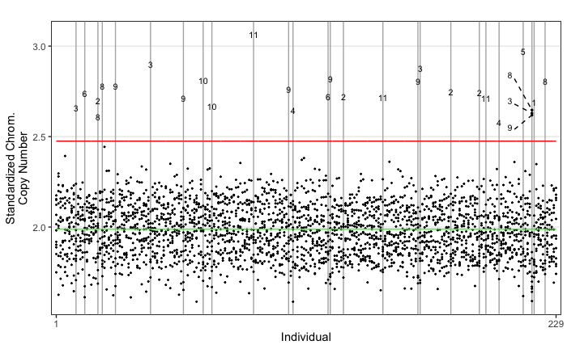

```r
fig2a_data <- with_cen %>%
  filter(Non_inducer == "WA077") %>%
  filter(snp_ploidy == "2x") %>%
  filter(sample_tot >= 2e4) %>%
  filter(manual_fp == "tp") %>%
  filter(UCD_Sample_Code != "MM155") %>%
  filter(chrom %in% sprintf("chr%0.2d", 1:12)) %>%
  dplyr::select(chrom, UCD_Sample_Code, UCD_Sample_Numeric, chromshort, chrom_normcov, chrom_ObsPerHI) %>%
  distinct() %>%
  arrange(UCD_Sample_Numeric) %>%
  mutate(sample_num_recode = floor( (seq(1:nrow(.)) -0.01)  / length(unique(.$chrom)))) %>%
  mutate(chromshort = str_remove(chrom, "chr")) %>%
  mutate(sample_num_recode = case_when(
    UCD_Sample_Numeric == 247 ~ 160,
    UCD_Sample_Numeric == 817 ~ 91,
    TRUE ~ sample_num_recode)) %>%
  mutate(chromshort = str_remove(chromshort, "^0")) %>%
  mutate(trisomic = ifelse(chrom_normcov >= mean(.$chrom_normcov) + 3 * sd(.$chrom_normcov), "whole chromosome", "segmental")) %>%
  group_by(UCD_Sample_Code) %>%
  ungroup()
cut_alleles_lo <- 20
cut_hi <- mean(fig2a_data$chrom_normcov) + 3 * sd(fig2a_data$chrom_normcov)
cut_lo <- mean(fig2a_data$chrom_normcov) - 3 * sd(fig2a_data$chrom_normcov)
tris <- fig2a_data$sample_num_recode[which(fig2a_data$chrom_normcov >= cut_hi)]
mons <- fig2a_data$sample_num_recode[which(fig2a_data$chrom_normcov <= cut_lo)]
adds <- fig2a_data$sample_num_recode[which(fig2a_data$chrom_ObsPerHI >= cut_alleles_lo)]
fig2a <- fig2a_data %>%
  filter(between(chrom_normcov, cut_lo, cut_hi)) %>%
  ggplot(., aes(x = sample_num_recode, y = chrom_normcov)) +
    geom_vline(xintercept = tris, color = "gray70") +
    geom_vline(xintercept = mons, color = "gray70") +
    geom_point(size = 0.3) +
    geom_text(data = filter(fig2a_data, chrom_normcov <= cut_lo), aes(label = chromshort), size = 2.8) +
    geom_text(data = filter(fig2a_data, chrom_normcov >= cut_hi & UCD_Sample_Code != "MM1114"), aes(label = chromshort), size = 2.8) +
    geom_point(data = filter(fig2a_data, chrom_normcov >= cut_hi & UCD_Sample_Code == "MM1114"), size = 0.5) +
    geom_line(y = mean(fig2a_data$chrom_normcov), color = "green") +
    geom_line(y = cut_hi, color = "red") +
    geom_line(y = cut_lo, color = "red") +
    # geom_vline(xintercept = 160) +
    annotate("segment", x=209, y=2.68, xend=217, yend=2.629554, linetype = "dashed") + # chromosome 3
    annotate("text", x=207, y=2.7, label="3", size=2.8) + # chromosome 3
    annotate("segment", x=209, y=2.82, xend=217, yend=2.646788, linetype = "dashed") + # chromosome 8
    annotate("text", x=207, y=2.84, label="8", size=2.8) + # chromosome 8
    annotate("segment", x=209, y =2.54, xend=217, yend=2.618737, linetype = "dashed") + # chromosome 9
    annotate("text", x =207, y =2.55, label="9", size=2.8) + # chromosome 9
    # ggtitle(paste0(unique(snpfam$ctrl_CIP), " Dihaploids")) +
    scale_x_continuous(limits = c(0,length(unique(fig2a_data$UCD_Sample_Code))-1),
                       breaks = c(0,length(unique(fig2a_data$UCD_Sample_Code))-1),
                       labels = c(1,length(unique(fig2a_data$UCD_Sample_Code))),
                       expand = c(0.01,0.01)) +
    labs(x = "Individual", y = "Standardized Chrom.\nCopy Number") +
    theme_bw() +
    theme(
      panel.grid.minor = element_blank(),
      panel.grid.major.x = element_blank(),
      panel.background=element_rect(fill="white",color="black"),
      # axis.title.x=element_text(size=18, margin = margin(-10,5,0,0)),
      # axis.title.y=element_text(size=18,angle= 90, vjust=2),
      # plot.title=element_text(size=20,face="bold",hjust=0,color="black"),
      # axis.text.x=element_text(size=18,color="black"),
      # axis.text.y=element_text(size=18,color="black"),
      plot.margin = margin(20, 5.5, 5.5, 5.5, "pt"))
fig2a
```

## Figure 2B: Chromosome parental origin: All WA.077-derived dihaploids

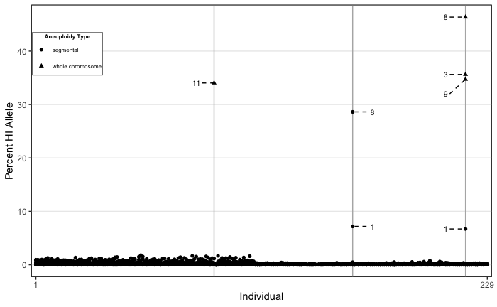

```r
fig2b <- fig2a_data %>%
  ggplot(., aes(x = sample_num_recode, y = chrom_ObsPerHI, shape = trisomic)) +
  geom_vline(xintercept = adds, color = "gray70") +
  geom_point() +

  # MM246 chromosome 11 annotation
  annotate("segment", x=84, y = 34.032912, xend=90, yend=34.032912, linetype="dashed") +
  annotate("text", x=81, y=34.032912, label="11", size=2.8) +
  # MM247 chromosome 8 annotation
  annotate("segment", x=167, y = 28.616813, xend=161, yend=28.616813, linetype="dashed") +
  annotate("text", x=170, y=28.616813, label="8", size=2.8) +
  annotate("segment", x=167, y = 7.196475, xend=161, yend=7.196475, linetype="dashed") +
  annotate("text", x=170, y=7.196475, label="1", size=2.8) +

  # MM1114 chromosome annotations
  annotate("segment", x=209, y=6.716918, xend=217, yend=6.716918, linetype = "dashed") + # chromosome 1
  annotate("text", x=207, y=6.716918, label="1", size = 2.8) + # chromosome 1
  annotate("segment", x=209, y=35.627298, xend=217, yend=35.627298, linetype = "dashed") + # chromosome 3
  annotate("text", x=207, y=35.627298, label="3", size = 2.8) + # chromosome 3
  annotate("segment", x=209, y=46.362805, xend=217, yend=46.362805, linetype = "dashed") + # chromosome 8
  annotate("text", x=207, y=46.362805, label="8", size=2.8) + # chromosome 8
  annotate("segment", x=209, y=32, xend=217, yend=34.716599, linetype = "dashed") + # chromosome 9
  annotate("text", x=207, y=32, label="9", size=2.8) + # chromosome 9
  scale_x_continuous(limits = c(0,length(unique(fig2a_data$UCD_Sample_Code))-1),
                     breaks = c(0,length(unique(fig2a_data$UCD_Sample_Code))-1),
                     labels = c(1,length(unique(fig2a_data$UCD_Sample_Code))),
                     expand = c(0.01,0.01)) +
  labs(x = "Individual", y = "Percent HI Allele", shape = "Aneuploidy Type") +
  theme_bw() +
  theme(
      panel.grid.minor = element_blank(),
      panel.grid.major.x = element_blank(),
      panel.background=element_rect(fill="white",color="black"),
      plot.margin = margin(5.5, 5.5, 5.5, 5.5, "pt"),
      legend.position = c(0.002, 0.82),
      legend.justification = "left",
      legend.title = element_text(size = 6, face = "bold"),
      legend.title.align = 0.5,
      legend.text = element_text(size = 6),
      legend.margin = margin(1,1,1,1),
      legend.box = "horizontal",
      legend.background = element_rect(color = "black", fill = "white", size = 0.2, linetype = "solid")
    )
fig2b
```

> Most aneuploids are due to an additional chromosome from the non-inducer parent. Furthermore, there is very little HI allele in dihaploids that don't have HI chromosomes, suggesting the impact of smaller introgressions is minimal. Based on this, I'm going to try pooling euploid dihaploids to use as a stand-in for the tetraploid parent. This allows chromosome parental origin analysis without having to sequence the tetraploid parent.

## Identify euploid dihaploids to pool as a stand-in for the tetraploid parent:

```r
dh_units <- read_tsv("../units.tsv", col_names = T, na = "NaN")
```

```r
clean_dh <- with_aneu_calls %>%
  filter(manual_fp != "fp") %>%
  group_by(UCD_Sample_Code) %>%
  mutate(chrnum = 24 + sum(call, na.rm = T)) %>%
  filter(sample_tot >= 2e4) %>%
  filter(Monica_ploidy == "2x") %>%
  filter(chrnum == 24) %>%
  select(UCD_Sample_Code, Non_inducer) %>%
  group_by(Non_inducer) %>%
  distinct() %>%
  ungroup() %>%
  rename(sample = UCD_Sample_Code) %>%
  left_join(., dh_units) %>%
  mutate(sample = paste0("clean_", str_remove(Non_inducer, "\\."), "_dihaploids")) %>%
  select(sample, unit, fq1, fq2, parhap) %>%
  mutate(fq1 = str_replace(fq1, "R1_001.fq.gz", "R1_001.fastq.gz")) %>%
  arrange(sample)
```

```r
parent_units <- read_tsv("../../1_parent_snps/units.tsv", col_names = T) %>%
  filter(sample != "WA077")
```

```r
clean_dh %>%
  filter(sample == "clean_WA077_dihaploids") %>%
  mutate(fq2 = replace_na(fq2, "NaN")) %>%
  # bind_rows(parent_units, .) %>%
  write_tsv(., "../../3_dihaploid_sub_test/units.tsv", col_names = T)
```

```
There were 12 warnings (use warnings() to see them)
```

```r
clean_dh %>%
  filter(sample != "clean_WA077_dihaploids") %>%
  mutate(fq2 = replace_na(fq2, "NaN")) %>%
  write_tsv(., "../../4_dihaploid_pools/units.tsv", col_names = T)
```